# Télécom Paris – Research Retreat 2025 in Belle-Île-en-Mer

Program and Information

June 24–27, 2025

[figure not shown]

# Research Retreat 2025

Welcome to the 2025 Research Retreat!

This document provides an overview of the program, including scheduled activities, presentations, and meals planned throughout our stay.

We hope this retreat offers a valuable opportunity to share ideas, explore new perspectives, and enjoy time together in an inspiring setting.

# 1 Program

| **Time** **Tuesday, June 24** | **Activity** **Tuesday, June 24** |
| --- | --- |
| 8:00 | Meeting at Montparnasse train station |
| 8:43–13:15 | Train journey |
| 13:30-15:00 | Lunch at La Capitainerie in Quiberon |
| 15:45–16:35 | Boat to Le Palais |
| 16:35–17:00 | Shuttle to the hotel and bike pick-up |
| 17:00–19:30 | Free time |
| 19:30–21:00 | Dinner at the hotel |
| **Wednesday, June 25** |  |
| 7:00–9:00 | Breakfast at the hotel |
| 9:30–11:30 | Research presentations |
| 11:30–12:00 | Bike ride to Le Palais |
| 12:00–13:00 | Lunch at La Touline crêperie |
| 13:00–14:00 | Visit of Le Palais |
| 14:30–17:00 | Atmos’Air Marine excursion |
| 17:00–19:30 | Free time |
| 19:30–21:00 | Dinner at the hotel |
| **Thursday, June 26** |  |
| 7:00–9:00 | Breakfast at the hotel |
| 9:30–11:30 | Research presentations |
| 11:30–12:00 | Bike ride to Sauzon |
| 12:15–13:00 | Lunch at Crêperie Glacier des Embruns à Sauzon in Sauzon |
| 13:00–16:00 | Walk to Pointe des Poulains |
| 16:00–17:00 | Guided tour of Fort Sarah-Bernhardt |
| 17:00–19:30 | Free time |
| 19:30–21:00 | Dinner at the hotel |
| **Friday, June 27** |  |
| 7:00–9:00 | Breakfast at the hotel |
| 9:30–11:30 | Research presentations |
| 12:00–13:30 | Lunch at the hotel |
| 13:30–14:00 | Shuttle to Le Palais |
| 14:15–15:00 | Return boat to Quiberon |
| 15:00–17:00 | Free time in Quiberon |
| 17:05–21:49 | Return train to Paris |

# 2 Presentations

## 2.1 Session 1 – Wednesday, June 25, 2025

- **9:30 – 10:00**
  - **Presenter:** Ivan Shchapov
    - **Title:** *Monetary Policy Shocks and Consumer Spending: Evidence from France*
- **10:00 – 10:30**
  - **Presenter:** Leonardo Leone
    - **Title:** *Massive parallelization of projection-based depths*
- **10:30 – 11:00**
  - **Presenter:** Chloé Breton
    - **Title:** *Spatial Interactions of Consumption, Presence, and Mobility : Evidence from Mobile Phone and Transaction Data*
- **11:00 – 11:30**
  - **Facilitators:** Patrick Waelbroeck, Marc Bourreau (Jean-Baptiste Guiffard or anyone who wants to join)
    - **Title:** *Brainstorming Session*

## 2.2 Session 2 – Thursday, June 26, 2025

- **9:30 – 10:00**
  - **Presenter:** Jean-Baptiste Guiffard
    - **Title:** *Measuring AI Substitutability and Complementarity in Developing Countries’ Labor Markets: Evidence from Online Job Postings Data*
- **10:00 – 10:30**
  - **Presenter:** Louis Pape
    - **Title:** *Tax Fraud in Digital Platforms: Evidence from the French Ridesharing Industry*
- **10:30 – 11:00**
  - **Presenter:** Gabrielle Gambuli
    - **Title:** *The Impact of Telework on Local Consumption: Evidence from Mobile Phone and Transaction Data*
- **11:00 – 11:15**
  - **Presenter:** Luca Rossi
    - **Title:** *Bologna città 30: Evaluation of Speed Reduction on Accidents*

## 2.3 Session 3 – Friday, June 27, 2025

- **9:30 – 10:30**
  - **Presenter:** Michele Fabi
    - **Title:** *A First Look at Smart Grids and Automated Market Makers for Energy Trading*
- **10:30 – 11:30**
  - **Department meeting**

# 3 General Information

## 3.1 Activities and Useful Links

A variety of group and individual activities are planned throughout the retreat. These include:

- [Bike rides across Belle-Île](https://www.belle-ile.com/decouvrir/mes-envies-de-rencontres-avec-un-site-dexception/belle-ile-vivifiante-parcourir-la-nature/balades-a-velos/12-idees-de-balades-et-boucles-a-velo/)
- [Excursion Atmos’Air Marine](https://www.belle-ile-marine.com/Tours.htm)
- [Visite du fort de Sarah-Bernard](https://www.ccbi.fr/lespace-sarah-bernhardt/)
- Brochure Thalasso & Spa & [Cahier tarifaire](https://hapi.mmcreation.com/hapidam/9fd69d74-5e15-4e85-a33e-6ec2cad765ba/CASTELCLARA-Cahier-Tarifaire-Thalasso_organized.pdf) au Castel Clara situé à 500 mètres (réservation en amont)
- [Plans de Belle-Île-en-Mer](https://www.calameo.com/read/006141237b2b447f1b736)
- [Hôtel website](https://hotelgrandlarge.com/)

## 3.2 What to Pack

Make sure you’re fully equipped to enjoy the retreat to the fullest:

- **Swimwear** – for the heated pool or a spontaneous beach swim
- **Comfortable walking/biking shoes** – for hikes and rides along the coastal trails
- **Sunscreen & hat or cap** – to protect yourself from the island sun
- **Light jacket or windbreaker** – for breezy evenings or ferry crossings
- **Warm layers** – even summer nights can get cool

## 3.3 Menus

Vegetarian options are available for every meal.

### 3.3.1 Tuesday, June 24

- **Lunch (1:30 PM) at La Capitainerie in Quiberon**
- **Dinner (7:30 PM) at the hotel:**
  - **Starter:** House-cured salmon gravlax, vegetable vinaigrette
  - **Main course:** Chicken supreme, roasted baby potatoes with parsley, thyme jus
  - **Dessert:** Chocolate & salted caramel entremet (salted butter caramel cream and chocolate ganache)

### 3.3.2 Wednesday, June 25

- **Lunch (12:00 PM) at La Touline crêperie in Le Palais**
- **Dinner (7:30 PM) at the hotel:**
  - **Starter:** Tuna tartare with sun-dried tomatoes
  - **Main course:** Roasted hake, mashed potatoes with seaweed and basil pesto
  - **Dessert:** Exotic entremet (coconut sponge and mousse, mango-passion fruit cream)

### 3.3.4 Friday, June 27

- **Lunch (12:00 PM) at the hotel:**
  - **Main course:** Slow-cooked pork cheek, creamy polenta and confit tomatoes
  - **Dessert:** Red fruit freshness (biscuit base, lime insert, red fruit mousse)

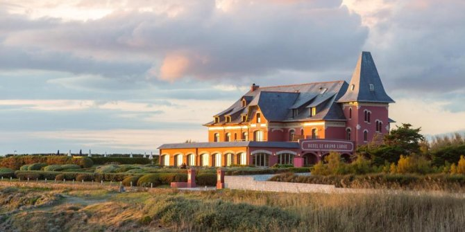

Nestled on the wild coast of Belle-Île-en-Mer, Le Grand Large is a charming 3-star hotel perched above the ocean in the peaceful Goulphar Bay. Housed in a historic manor, the hotel blends authenticity and elegance, offering an intimate setting ideal for rest, reflection, and sunset gazing.

From the panoramic heated pool to the warm (Don’t forget your swimsuit), light-filled rooms overlooking the Atlantic or the moorlands, every detail is designed for comfort and serenity. The hotel also features a gourmet restaurant, family-friendly suites, and direct access to the island’s most scenic hiking and biking trails.

Located just 500 meters from the renowned Castel Clara thalassotherapy center, Le Grand Large is the perfect base for combining work, wellness, and discovery during your stay on the island.

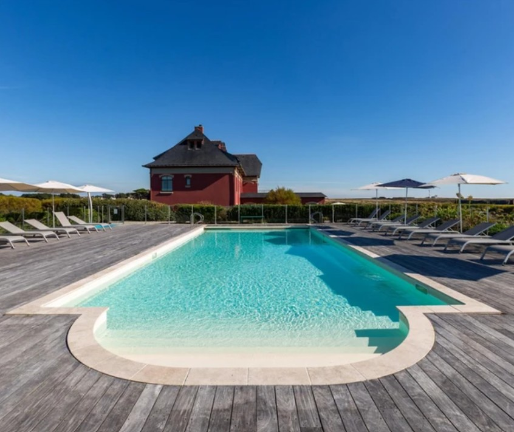

Swmming pool